# **General Overview**

### **Background:**

Cars4U is a budding tech start-up that aims to take advantage of the huge demand for used cars. As sales of new cars have slowed down in the recent past, the pre-owned car market has continued to grow over the past years and is larger than the new car market now.

### **Objective:**

Unlike new cars, where price and supply are fairly deterministic and managed by OEMs (Original Equipment Manufacturer), with used cars there is a huge uncertainty in both pricing and supply. Because of this, the pricing scheme of these used cars becomes important in order to grow in the market. Therefore, this project seeks to:

1. Come up with a pricing model that can effectively predict the price of used cars, by building a linear regression model to predict the prices of used cars.
2. Explore & visualize the dataset, to show the relationship between the attributes of cars and how it affects the price of cars.
3. Extract & generate a set of actionable insights and recommendations that can help the business in devising profitable strategies using differential pricing.

### **Key Questions:**

1. How do the different attributes such as number of seats, Fuel type, etc... affect the price of a used car?
2. How can we significantly decrease the amount of uncertainty we have to deal with when pricing used cars.
3. What insights & recommendations can be derived that will help the company develop the optimal pricing strategy?

### **Data Description:**

The data contains the different attributes of used cars sold in different locations.

The detailed data dictionary is given below:

- **S.No.:-** Serial number
- **Name :-** Name of the car which includes brand name and model name
- **Location :-** Location in which the car is being sold or is available for purchase (cities)
- **Year :-** Manufacturing year of the car
- **Kilometers_driven :-** The total kilometers (a unit used to measure length or distance) driven in the car by the previous owner(s)
- **Fuel_Type :-** The type of fuel used by the car (Petrol, Diesel, Electric, CNG, LPG)
- **Transmission :-** The type of transmission used by the car (Automatic/Manual)
- **Owner :-** Type of ownership
- **Mileage :-** The standard mileage offered by the car company in kmpl or km/kg
- **Engine :-** The displacement volume of the engine in CC
- **Power :-** The maximum power of the engine in bhp
- **Seats :-** The number of seats in the car
- **New_Price :-** The price of a new car of the same model in INR Lakhs (1 Lakh INR = 100,000 INR)
- **Price :-** The price of the used car in INR Lakhs

# **Sanity Checks**

### **Importing Necessary Libraries**

```python
# Making the Python code more structured automatically
%load_ext nb_black

# Import numpy and pandas: Libraries that handle the reading and manipulating data & numbers
import numpy as np
import pandas as pd

# Import matplotlib & seaborn: Libraries that handle data visualization
import matplotlib.pyplot as plt

%matplotlib inline

import seaborn as sns

sns.set(
    color_codes=True
)  # -----This adds a background color to all the plots created using seaborn

# Allow the use of Display via interactive Python
from IPython.display import display

# Ignore warnings
import warnings

warnings.filterwarnings("ignore")

# Import library for exploratory visualization of missing data.
import missingno as ms

# Removes the limit for the number of displayed columns
pd.set_option("display.max_columns", None)
# Sets the limit for the number of displayed rows
pd.set_option("display.max_rows", 200)

# To split the data into train and test
from sklearn.model_selection import train_test_split

# To build linear regression_model
from sklearn.linear_model import LinearRegression

# To check model performance
from sklearn.metrics import mean_absolute_error, mean_squared_error, r2_score

# Import Sequential Feature Selector & the plot
from mlxtend.feature_selection import SequentialFeatureSelector as SFS
from mlxtend.plotting import plot_sequential_feature_selection as plot_sfs

print("Loading Libraries... Done.")
```

```
Loading Libraries... Done.
```

### **Loading the Dataset**

```python
# Load the dataset of Cars4U (c4u)
path = "used_cars_data.csv"
c4u_data = pd.read_csv(path)

# copying data to another variable to avoid any changes to original data
df = c4u_data.copy()

print("Loading Dataset... Done.")
```

```
Loading Dataset... Done.
```

# **Data Overview**

### **Checking a few rows of the Dataset**

```python
# Checking the top 5, botom 5 and 10 random rows

display(df.head())  # -----looking at head (top 5 observations)
display(df.tail())  # -----looking at tail (bottom 5 observations)
display(
    df.sample(15, random_state=15)
)  # -----10 random sample of observations from the data
```

|  | S.No. | Name | Location | Year | Kilometers_Driven | Fuel_Type | Transmission | Owner_Type | Mileage | Engine | Power | Seats | New_Price | Price |
| --- | --- | --- | --- | --- | --- | --- | --- | --- | --- | --- | --- | --- | --- | --- |
| 0 | 0 | Maruti Wagon R LXI CNG | Mumbai | 2010 | 72000 | CNG | Manual | First | 26.6 km/kg | 998 CC | 58.16 bhp | 5.0 | 5.51 | 1.75 |
| 1 | 1 | Hyundai Creta 1.6 CRDi SX Option | Pune | 2015 | 41000 | Diesel | Manual | First | 19.67 kmpl | 1582 CC | 126.2 bhp | 5.0 | 16.06 | 12.50 |
| 2 | 2 | Honda Jazz V | Chennai | 2011 | 46000 | Petrol | Manual | First | 18.2 kmpl | 1199 CC | 88.7 bhp | 5.0 | 8.61 | 4.50 |
| 3 | 3 | Maruti Ertiga VDI | Chennai | 2012 | 87000 | Diesel | Manual | First | 20.77 kmpl | 1248 CC | 88.76 bhp | 7.0 | 11.27 | 6.00 |
| 4 | 4 | Audi A4 New 2.0 TDI Multitronic | Coimbatore | 2013 | 40670 | Diesel | Automatic | Second | 15.2 kmpl | 1968 CC | 140.8 bhp | 5.0 | 53.14 | 17.74 |

|  | S.No. | Name | Location | Year | Kilometers_Driven | Fuel_Type | Transmission | Owner_Type | Mileage | Engine | Power | Seats | New_Price | Price |
| --- | --- | --- | --- | --- | --- | --- | --- | --- | --- | --- | --- | --- | --- | --- |
| 7248 | 7248 | Volkswagen Vento Diesel Trendline | Hyderabad | 2011 | 89411 | Diesel | Manual | First | 20.54 kmpl | 1598 CC | 103.6 bhp | 5.0 | 13.23 | NaN |
| 7249 | 7249 | Volkswagen Polo GT TSI | Mumbai | 2015 | 59000 | Petrol | Automatic | First | 17.21 kmpl | 1197 CC | 103.6 bhp | 5.0 | 10.15 | NaN |
| 7250 | 7250 | Nissan Micra Diesel XV | Kolkata | 2012 | 28000 | Diesel | Manual | First | 23.08 kmpl | 1461 CC | 63.1 bhp | 5.0 | 9.47 | NaN |
| 7251 | 7251 | Volkswagen Polo GT TSI | Pune | 2013 | 52262 | Petrol | Automatic | Third | 17.2 kmpl | 1197 CC | 103.6 bhp | 5.0 | 10.15 | NaN |
| 7252 | 7252 | Mercedes-Benz E-Class 2009-2013 E 220 CDI Avan... | Kochi | 2014 | 72443 | Diesel | Automatic | First | 10.0 kmpl | 2148 CC | 170 bhp | 5.0 | 86.97 | NaN |

|  | S.No. | Name | Location | Year | Kilometers_Driven | Fuel_Type | Transmission | Owner_Type | Mileage | Engine | Power | Seats | New_Price | Price |
| --- | --- | --- | --- | --- | --- | --- | --- | --- | --- | --- | --- | --- | --- | --- |
| 6694 | 6694 | Skoda Superb Style 1.8 TSI AT | Mumbai | 2016 | 71000 | Petrol | Automatic | First | 14.67 kmpl | 1798 CC | 177.46 bhp | 5.0 | 33.360 | NaN |
| 5146 | 5146 | Audi Q7 3.0 TDI quattro | Coimbatore | 2014 | 118218 | Diesel | Automatic | First | 12.07 kmpl | 2967 CC | 241.4 bhp | 7.0 | 101.960 | 31.41 |
| 914 | 914 | Audi Q3 2.0 TDI | Chennai | 2014 | 60000 | Diesel | Automatic | First | 15.73 kmpl | 1968 CC | 174.33 bhp | 5.0 | 44.800 | 20.00 |
| 861 | 861 | Hyundai i20 Magna 1.2 | Hyderabad | 2014 | 70089 | Petrol | Manual | First | 18.6 kmpl | 1197 CC | 81.83 bhp | 5.0 | 10.250 | 5.35 |
| 5936 | 5936 | Volkswagen Vento 1.5 TDI Highline | Bangalore | 2014 | 58000 | Diesel | Manual | First | 20.34 kmpl | 1498 CC | 103.2 bhp | 5.0 | 13.230 | 6.50 |
| 171 | 171 | Hyundai i10 Magna 1.2 | Delhi | 2013 | 60000 | Petrol | Manual | First | 20.36 kmpl | 1197 CC | 78.9 bhp | 5.0 | 10.250 | 2.75 |
| 1877 | 1877 | Toyota Innova Crysta 2.8 GX AT | Kochi | 2019 | 10601 | Diesel | Automatic | First | 11.36 kmpl | 2755 CC | 171.5 bhp | 7.0 | 20.740 | 19.65 |
| 2343 | 2343 | Hyundai Santro AT | Hyderabad | 2006 | 74483 | Petrol | Automatic | First | 0.0 kmpl | 999 CC | NaN | 5.0 | 4.550 | 2.30 |
| 6739 | 6739 | Honda Mobilio S i DTEC | Hyderabad | 2015 | 76000 | Diesel | Manual | First | 24.2 kmpl | 1498 CC | 98.6 bhp | 7.0 | 13.580 | NaN |
| 1570 | 1570 | Mercedes-Benz New C-Class C 200 Avantgarde Edi... | Kochi | 2011 | 29813 | Petrol | Automatic | Second | 14.74 kmpl | 1991 CC | 181.03 bhp | 5.0 | 49.490 | 11.50 |
| 6310 | 6310 | Toyota Innova 2.5 G (Diesel) 8 Seater | Mumbai | 2007 | 194000 | Diesel | Manual | First | 12.99 kmpl | 2494 CC | 100.6 bhp | 8.0 | 24.010 | NaN |
| 3393 | 3393 | Skoda Octavia L and K 1.9 TDI MT | Hyderabad | 2006 | 121000 | Diesel | Manual | Second | 16.4 kmpl | 1896 CC | 90 bhp | 5.0 | 25.830 | 2.50 |
| 3851 | 3851 | Renault Koleos 2.0 Diesel | Delhi | 2013 | 65000 | Diesel | Automatic | Second | 13.73 kmpl | 1995 CC | 148 bhp | 5.0 | 15.050 | 7.50 |
| 269 | 269 | Renault Duster 110PS Diesel RXZ Option | Delhi | 2016 | 26000 | Diesel | Manual | First | 19.64 kmpl | 1461 CC | 108.45 bhp | 5.0 | 15.050 | 10.00 |
| 4625 | 4625 | Toyota Corolla Altis Diesel D4DJ | Delhi | 2011 | 89401 | Diesel | Manual | First | 21.43 kmpl | 1364 CC | 87.2 bhp | 5.0 | 21.085 | 4.50 |

*Observations*

- *We can drop `S.No.` column as it will not be contributing to our analysis in any way*

### **Checking the shape of the dataset**

```python
# -----Print the dimension of the data
print("The dataset has ", df.shape[0], " rows and ", df.shape[1], " columns")
```

```
The dataset has  7253  rows and  14  columns
```

*Observations*

- The dataframe has 7253 rows and 14 columns

### **Checking the Data Types & General Information of the Dataset**

```python
# -----Counting the number of columns per data type
df.dtypes.value_counts()
```

```
object     8
int64      3
float64    3
dtype: int64
```

```python
# -----Displaying information about features of the Dataset
df.info()
```

```
<class 'pandas.core.frame.DataFrame'>
RangeIndex: 7253 entries, 0 to 7252
Data columns (total 14 columns):
 #   Column             Non-Null Count  Dtype
---  ------             --------------  -----
 0   S.No.              7253 non-null   int64
 1   Name               7253 non-null   object
 2   Location           7253 non-null   object
 3   Year               7253 non-null   int64
 4   Kilometers_Driven  7253 non-null   int64
 5   Fuel_Type          7253 non-null   object
 6   Transmission       7253 non-null   object
 7   Owner_Type         7253 non-null   object
 8   Mileage            7251 non-null   object
 9   Engine             7207 non-null   object
 10  Power              7078 non-null   object
 11  Seats              7200 non-null   float64
 12  New_Price          7253 non-null   float64
 13  Price              6019 non-null   float64
dtypes: float64(3), int64(3), object(8)
memory usage: 793.4+ KB
```

*Observations*

- *There are 8 object type columns while the other 6 columns are numerical.*
- *There are Missing Values in `Mileage`, `Engine`, `Power`, `Seats` and `Price`.*
- *`Mileage`, `Engine` and `Power` columns contain tailing string characters and are read as object datatype. These string characters will be removed and the columns will be converted to numeric as should be*
- *As stated earlier, we will go ahead and drop the `S.No.` column.*
- *`Price` is the dependent variable*

### **Getting the Statistical Summary for the Dataset**

```python
# -----Displaying Statistical Summary of Numerical Data
df.describe().T.round(2)
```

|  | count | mean | std | min | 25% | 50% | 75% | max |
| --- | --- | --- | --- | --- | --- | --- | --- | --- |
| S.No. | 7253.0 | 3626.00 | 2093.91 | 0.00 | 1813.00 | 3626.00 | 5439.00 | 7252.0 |
| Year | 7253.0 | 2013.37 | 3.25 | 1996.00 | 2011.00 | 2014.00 | 2016.00 | 2019.0 |
| Kilometers_Driven | 7253.0 | 58699.06 | 84427.72 | 171.00 | 34000.00 | 53416.00 | 73000.00 | 6500000.0 |
| Seats | 7200.0 | 5.28 | 0.81 | 0.00 | 5.00 | 5.00 | 5.00 | 10.0 |
| New_Price | 7253.0 | 21.31 | 24.26 | 3.91 | 7.88 | 11.30 | 21.69 | 375.0 |
| Price | 6019.0 | 9.48 | 11.19 | 0.44 | 3.50 | 5.64 | 9.95 | 160.0 |

*Observations*

- *The oldest car was made in 1996 and the newest car was made in 2019.*
- *`Kilometers_Driven` has a wide range indicating that there is a wide range of usage among the second-hand cars.*
- *It's interesting to note that there is a car(s) with no seats (zero).*
- *As expected `New_Price` (price of a new car of the same model) is gererally higher than `Price` (price of the used car).*

```python
# -----Displaying Statistical Summary of Categorical Data
df.describe(include=["object"]).T
```

|  | count | unique | top | freq |
| --- | --- | --- | --- | --- |
| Name | 7253 | 2041 | Mahindra XUV500 W8 2WD | 55 |
| Location | 7253 | 11 | Mumbai | 949 |
| Fuel_Type | 7253 | 5 | Diesel | 3852 |
| Transmission | 7253 | 2 | Manual | 5204 |
| Owner_Type | 7253 | 4 | First | 5952 |
| Mileage | 7251 | 450 | 17.0 kmpl | 207 |
| Engine | 7207 | 150 | 1197 CC | 732 |
| Power | 7078 | 385 | 74 bhp | 280 |

*Observations*

- `Mileage`, `Engine` & `Power`will be "cleaned" and converted to numerical variables.
- *The remaining object datatypes will be converted to "Category" to reduce the space required to store the dataframe. It also helps in analysis*

### **Checking Missing Values**

```python
# Checking missing values across each columns

c_missing = pd.Series(df.isnull().sum(), name="Missing Count")  # -----Count Missing

p_missing = pd.Series(
    round(df.isnull().sum() / df.shape[0] * 100, 2), name="% Missing"
)  # -----Percentage Missing


# Combine into 1 Dataframe
missing_df = pd.concat([c_missing, p_missing], axis=1)

# Display missing info
display(missing_df)
```

|  | Missing Count | % Missing |
| --- | --- | --- |
| S.No. | 0 | 0.00 |
| Name | 0 | 0.00 |
| Location | 0 | 0.00 |
| Year | 0 | 0.00 |
| Kilometers_Driven | 0 | 0.00 |
| Fuel_Type | 0 | 0.00 |
| Transmission | 0 | 0.00 |
| Owner_Type | 0 | 0.00 |
| Mileage | 2 | 0.03 |
| Engine | 46 | 0.63 |
| Power | 175 | 2.41 |
| Seats | 53 | 0.73 |
| New_Price | 0 | 0.00 |
| Price | 1234 | 17.01 |

```python
# Check for any possible corrupt values like 0.0 and replace with Nan before proceeding
num_col = df.select_dtypes(include=np.number).columns.tolist()

for col in num_col:
    df[col] = df[col].replace(0.0, np.nan)
```

```python
# Checking missing values across each columns to see if there's any effect

c_missing = pd.Series(df.isnull().sum(), name="Missing Count")  # -----Count Missing

p_missing = pd.Series(
    round(df.isnull().sum() / df.shape[0] * 100, 2), name="% Missing"
)  # -----Percentage Missing


# Combine into 1 Dataframe
missing_df = pd.concat([c_missing, p_missing], axis=1)

# Display missing info
display(missing_df)
```

|  | Missing Count | % Missing |
| --- | --- | --- |
| S.No. | 1 | 0.01 |
| Name | 0 | 0.00 |
| Location | 0 | 0.00 |
| Year | 0 | 0.00 |
| Kilometers_Driven | 0 | 0.00 |
| Fuel_Type | 0 | 0.00 |
| Transmission | 0 | 0.00 |
| Owner_Type | 0 | 0.00 |
| Mileage | 2 | 0.03 |
| Engine | 46 | 0.63 |
| Power | 175 | 2.41 |
| Seats | 54 | 0.74 |
| New_Price | 0 | 0.00 |
| Price | 1234 | 17.01 |

*Observations*

- *`Seats` has one corrupt value of 0.0 and it has been converted to nan. Changing the number of missing values from 53 to 54*
- *We are ignoring `S.No.` because it will be dropped later.*
- *`Mileage` (0.03%), `Engine` (0.63%), `Power` (2.41%) and `Seats` (0.73%) have comparatively lesser missing values. All below 2.5%. We will be treating these accordingly.*
- *The `Price` column has 1234 (17%) missing values, which is significant.*
- *Since `Price` is our target variable, we will be dropping the missing values...It is generally preferred to drop the missing values in the target variable.*

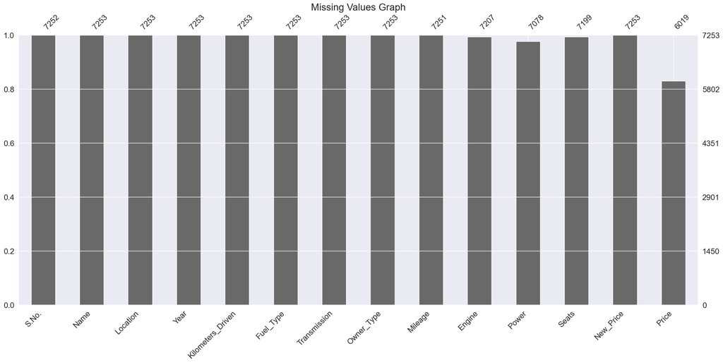

```python
# Visual Exploration of Missing Values
# Plot missing values across each columns
plt.title("Missing Values Graph", fontsize=20)
ms.bar(df)
```

### **Checking Catigorical Variables**

```python
# -----Displaying Value Count of relevant Categorical columns in Pecentages
cati_col = ["Location", "Fuel_Type", "Transmission", "Owner_Type"]

for col in cati_col:
    print("/" * 40)
    print(df[col].value_counts(normalize=True) * 100, "\n")
```

```
////////////////////////////////////////
Mumbai        13.084241
Hyderabad     12.077761
Coimbatore    10.643872
Kochi         10.643872
Pune          10.547360
Delhi          9.099683
Kolkata        9.016958
Chennai        8.148352
Jaipur         6.879912
Bangalore      6.066455
Ahmedabad      3.791535
Name: Location, dtype: float64

////////////////////////////////////////
Diesel      53.109058
Petrol      45.843099
CNG          0.854819
LPG          0.165449
Electric     0.027575
Name: Fuel_Type, dtype: float64

////////////////////////////////////////
Manual       71.749621
Automatic    28.250379
Name: Transmission, dtype: float64

////////////////////////////////////////
First             82.062595
Second            15.883083
Third              1.888874
Fourth & Above     0.165449
Name: Owner_Type, dtype: float64
```

*Observations*

- *`CNG`, `LPG`, `Electric` combined constitute only 1% of `Fuel_Type`.*
- *`Third` & `Fourth & Above` combined constiture only 2% `Owner_Type`.*

# **Data Preprocessing**

### **Dropping Rows & Column**

```python
# --------------------
# Dropping S.No. Column as it will not be contributing to our analysis in any way
# --------------------

df.drop("S.No.", axis="columns", inplace=True)
```

```python
# --------------------
# Drop missing values in target variable 'Price'.
# This will mean that dropping the affected rows
# --------------------

df = df.dropna(subset=["Price"])
```

```python
# Display Info and Shape of the dataframe

display(df.shape)
df.info()
```

```
(6019, 13)
```

```
<class 'pandas.core.frame.DataFrame'>
Int64Index: 6019 entries, 0 to 6018
Data columns (total 13 columns):
 #   Column             Non-Null Count  Dtype
---  ------             --------------  -----
 0   Name               6019 non-null   object
 1   Location           6019 non-null   object
 2   Year               6019 non-null   int64
 3   Kilometers_Driven  6019 non-null   int64
 4   Fuel_Type          6019 non-null   object
 5   Transmission       6019 non-null   object
 6   Owner_Type         6019 non-null   object
 7   Mileage            6017 non-null   object
 8   Engine             5983 non-null   object
 9   Power              5876 non-null   object
 10  Seats              5976 non-null   float64
 11  New_Price          6019 non-null   float64
 12  Price              6019 non-null   float64
dtypes: float64(3), int64(2), object(8)
memory usage: 658.3+ KB
```

*Observations*

- *The Target Variable, `Price`, now has no missing value*
- *There are now 6019 rows and 13 columns*

### **Fixing Datatypes**

```python
#--------------------
# The concerned object datatypes will be converted to "Category"
# to reduce the space required to store the dataframe. It also helps in analysis*
#--------------------

df["Name"]=df["Name"].astype("category")
df["Location"]=df["Location"].astype("category")
df["Fuel_Type"]=df["Fuel_Type"].astype("category")
df["Transmission"]=df["Transmission"].astype("category")
df["Owner_Type"]=df["Owner_Type"].astype("category")
```

```python
#--------------------
# Processing & identifying Object Columns that should be Numerical
#--------------------

num_values = []

#This code will add all the columns we want to convert form object to numerical into a list
for colname in df.columns[df.dtypes == 'object']:  # only need to consider string columns
    if df[colname].str.endswith('pl').any() or df[colname].str.endswith('kg').any() or df[colname].str.endswith('CC').any() or df[colname].str.endswith('bhp').any() or df[colname].str.endswith('Lakh').any():
        # using `.str` to use an element-wise string method to select the required columns
        num_values.append(colname)

print(num_values)
```

```
['Mileage', 'Engine', 'Power']
```

```python
# -----------
# User defined function: This function splits the string from the numerical values in the columns
# This function will also drop the string and convert to float datatype, ensuring a cleaner and faster code
# -----------


def obj_2_num(n):
    if isinstance(n, str):  # checks if the columns are string datatype
        if n.endswith("kmpl"):
            return float(n.split("kmpl")[0])
        elif n.endswith("km/kg"):
            return float(n.split("km/kg")[0])
        elif n.endswith("CC"):
            return float(n.split("CC")[0])
        elif n.endswith("bhp"):
            return float(n.split("bhp")[0])
    else:
        return np.nan
```

```python
# ------------------
# Call the obj_2_num() function to clean the concerned object columns
# and convert them into Numerical columns
# ------------------

for colname in num_values:
    df[colname] = df[colname].apply(
        obj_2_num
    )  # applying above function to the column list
```

```python
df.info()
```

```
<class 'pandas.core.frame.DataFrame'>
Int64Index: 6019 entries, 0 to 6018
Data columns (total 13 columns):
 #   Column             Non-Null Count  Dtype
---  ------             --------------  -----
 0   Name               6019 non-null   category
 1   Location           6019 non-null   category
 2   Year               6019 non-null   int64
 3   Kilometers_Driven  6019 non-null   int64
 4   Fuel_Type          6019 non-null   category
 5   Transmission       6019 non-null   category
 6   Owner_Type         6019 non-null   category
 7   Mileage            6017 non-null   float64
 8   Engine             5983 non-null   float64
 9   Power              5876 non-null   float64
 10  Seats              5976 non-null   float64
 11  New_Price          6019 non-null   float64
 12  Price              6019 non-null   float64
dtypes: category(5), float64(6), int64(2)
memory usage: 538.6 KB
```

*Observations*

- *We now have 5 Categorical variables and 8 Numerical variables.*
- *`Mileage`, `Engine` & `Power` have been converted to Numerical variables.*

```python
df.describe(include=["category"]).T
```

|  | count | unique | top | freq |
| --- | --- | --- | --- | --- |
| Name | 6019 | 1876 | Mahindra XUV500 W8 2WD | 49 |
| Location | 6019 | 11 | Mumbai | 790 |
| Fuel_Type | 6019 | 5 | Diesel | 3205 |
| Transmission | 6019 | 2 | Manual | 4299 |
| Owner_Type | 6019 | 4 | First | 4929 |

*Observations*

- *There are 1876 total unique Cars*
- *More cars are sold in Mumbai*
- *Diesel is the preffered Fuel Type*
- *Most of the cars sold are Manual Transmission & have only had one previous owner.*

### **More Data Wrangling**

```python
# ------------------------
# The following code groups the cars by Brand and Model
# ...this makes the data more manageable.
# ------------------------

df[["Car_Brand", "Car_Model"]] = df.Name.str.split(
    n=1, expand=True
)  # splitting the Brand and the car model

# Get the unique Brand_names and models
display(df["Car_Brand"].unique())
display(df["Car_Model"].unique())

# Get the count of unique Brand_names and models
print("Number of Brands:", (df["Car_Brand"].nunique()))
print("Number of Models:", (df["Car_Model"].nunique()))
```

```
array(['Maruti', 'Hyundai', 'Honda', 'Audi', 'Nissan', 'Toyota',
       'Volkswagen', 'Tata', 'Land', 'Mitsubishi', 'Renault',
       'Mercedes-Benz', 'BMW', 'Mahindra', 'Ford', 'Porsche', 'Datsun',
       'Jaguar', 'Volvo', 'Chevrolet', 'Skoda', 'Mini', 'Fiat', 'Jeep',
       'Smart', 'Ambassador', 'Isuzu', 'ISUZU', 'Force', 'Bentley',
       'Lamborghini'], dtype=object)
```

```
array(['Wagon R LXI CNG', 'Creta 1.6 CRDi SX Option', 'Jazz V', ...,
       'Polo IPL II 1.2 Petrol Highline', 'Bolt Revotron XT',
       'Xylo D4 BSIV'], dtype=object)
```

```
Number of Brands: 31
Number of Models: 1876
```

*Observations*

- *There are 31 unique Brands and there are 1876 Models*
- *Land Rover is mentioned as Land & the Brand Isuzu is mentioned twice*

```python
# Correcting the brands issues observed above.

df["Car_Brand"] = df["Car_Brand"].replace("Land", "Land_Rover")
df["Car_Brand"] = df["Car_Brand"].replace("ISUZU", "Isuzu")
df["Car_Brand"].value_counts()
```

```
Maruti           1211
Hyundai          1107
Honda             608
Toyota            411
Mercedes-Benz     318
Volkswagen        315
Ford              300
Mahindra          272
BMW               267
Audi              236
Tata              186
Skoda             173
Renault           145
Chevrolet         121
Nissan             91
Land_Rover         60
Jaguar             40
Fiat               28
Mitsubishi         27
Mini               26
Volvo              21
Porsche            18
Jeep               15
Datsun             13
Isuzu               3
Force               3
Smart               1
Ambassador          1
Bentley             1
Lamborghini         1
Name: Car_Brand, dtype: int64
```

*Observations*

- *Maruti & Hyundai are the most popular cars brands*
- *Honda & Toyota are the next most popular brands*
- *Expensive luxury car brands like `Bentley` & `Lamborghini` are very few*

### **More Missing Value treatment**

We have missing values in Power, Engine, Mileage and Seats. We will replace the missing values with its median value.

```python
# Get the numerical columns
numeric_columns = df.select_dtypes(include=np.number).columns.tolist()

# Replace the missing values with the median
numeric_columns.remove("Price")  # Remove the dependent variable
medianFiller = lambda x: x.fillna(x.median())
df[numeric_columns] = df[numeric_columns].apply(medianFiller, axis=0)
```

```python
df.info()
```

```
<class 'pandas.core.frame.DataFrame'>
Int64Index: 6019 entries, 0 to 6018
Data columns (total 15 columns):
 #   Column             Non-Null Count  Dtype
---  ------             --------------  -----
 0   Name               6019 non-null   category
 1   Location           6019 non-null   category
 2   Year               6019 non-null   int64
 3   Kilometers_Driven  6019 non-null   int64
 4   Fuel_Type          6019 non-null   category
 5   Transmission       6019 non-null   category
 6   Owner_Type         6019 non-null   category
 7   Mileage            6019 non-null   float64
 8   Engine             6019 non-null   float64
 9   Power              6019 non-null   float64
 10  Seats              6019 non-null   float64
 11  New_Price          6019 non-null   float64
 12  Price              6019 non-null   float64
 13  Car_Brand          6019 non-null   object
 14  Car_Model          6019 non-null   object
dtypes: category(5), float64(6), int64(2), object(2)
memory usage: 632.6+ KB
```

```python
df.describe().T.round(2)
```

|  | count | mean | std | min | 25% | 50% | 75% | max |
| --- | --- | --- | --- | --- | --- | --- | --- | --- |
| Year | 6019.0 | 2013.36 | 3.27 | 1998.00 | 2011.00 | 2014.00 | 2016.00 | 2019.00 |
| Kilometers_Driven | 6019.0 | 58738.38 | 91268.84 | 171.00 | 34000.00 | 53000.00 | 73000.00 | 6500000.00 |
| Mileage | 6019.0 | 18.13 | 4.58 | 0.00 | 15.17 | 18.15 | 21.10 | 33.54 |
| Engine | 6019.0 | 1620.51 | 599.64 | 72.00 | 1198.00 | 1493.00 | 1969.00 | 5998.00 |
| Power | 6019.0 | 112.88 | 53.28 | 34.20 | 78.00 | 97.70 | 138.03 | 560.00 |
| Seats | 6019.0 | 5.28 | 0.80 | 2.00 | 5.00 | 5.00 | 5.00 | 10.00 |
| New_Price | 6019.0 | 21.50 | 24.33 | 3.91 | 7.88 | 11.30 | 21.77 | 375.00 |
| Price | 6019.0 | 9.48 | 11.19 | 0.44 | 3.50 | 5.64 | 9.95 | 160.00 |

*Observations*

- *`Year`: Mean Year of car's is 2013 which is one year short of median. Year starts from 1998 till 2019 implying older to latest car models*
- *`Kilometers_Driven`: The Mean is slightly higher than the median, but the max value is very hight, suggesting outliers*
- *`Mileage`: The Mean and Median of Mileage are close*
- *`Seats`: The lowest is a 2 seater. The data cleaning took care of the zero seater we observed earlier.*
- *`Engine & Power & Price`: The Mean value is higher than the median for all three variables.*
- *Average `Price` is at 9.48 Lakhs. The Variance (11.19) is greater than the Mean which suggests wide distribution(skewness) of data.*

## **Feature Engineering**

### **Binning the Car Names based on Price**

- *We have 31 car brands and much more individual models (1876).*
- *We will bin them according to their Price ranges from economic/cheaper (Tier1) cars to luxury/expensive cars (Tier6)*

```python
# -----
# We want our analysis to be Brand angnostic
# This Code is to Bin cars into 6 Tiers
# -----

# Car_Brand and Cra_Model are no longer needed for Analysis
# df.drop(["Car_Brand", "Car_Model"], axis=1, inplace=True)

df["Car_Class"] = pd.cut(
    df["Price"],
    [-np.inf, 5.0, 10.0, 20.0, 45.0, 75.0, np.inf],
    labels=["Tier1", "Tier2", "Tier3", "Tier4", "Tier5", "Tier6"],
)

df["Car_Class"].value_counts()
```

```
Tier1    2660
Tier2    1877
Tier3     793
Tier4     566
Tier5     111
Tier6      12
Name: Car_Class, dtype: int64
```

```python
df.groupby(["Car_Class", "Car_Brand"])["Price"].sum()
```

```
Car_Class  Car_Brand
Tier1      Ambassador          1.35
           Audi                0.00
           BMW                 0.00
           Bentley             0.00
           Chevrolet         259.56
           Datsun             39.64
           Fiat               53.84
           Force               0.00
           Ford              403.73
           Honda            1112.92
           Hyundai          1984.19
           Isuzu               0.00
           Jaguar              0.00
           Jeep                0.00
           Lamborghini         0.00
           Land_Rover          0.00
           Mahindra          209.21
           Maruti           2354.85
           Mercedes-Benz      13.55
           Mini                0.00
           Mitsubishi         14.30
           Nissan            183.29
           Porsche             2.02
           Renault           238.71
           Skoda             248.02
           Smart               3.00
           Tata              392.84
           Toyota            339.78
           Volkswagen        649.38
           Volvo               0.00
Tier2      Ambassador          0.00
           Audi              136.21
           BMW               230.88
           Bentley             0.00
           Chevrolet         108.82
           Datsun              0.00
           Fiat               37.70
           Force              16.00
           Ford              889.09
```

[output cut: 127 more lines]

```
           Mahindra            0.00
           Maruti              0.00
           Mercedes-Benz     331.76
           Mini                0.00
           Mitsubishi          0.00
           Nissan              0.00
           Porsche             0.00
           Renault             0.00
           Skoda               0.00
           Smart               0.00
           Tata                0.00
           Toyota              0.00
           Volkswagen          0.00
           Volvo               0.00
Name: Price, dtype: float64
```

*Observations*

- *There are 19 Brands and 2660 cars in Tier1 while there are 5 Brands & 12 Cars in Tier6*

### **Grouping Location into Region**

- *This will reduce total categories of location from 11 to just 4 (four) Regions.*

```python
# -------
# Gathered Domain Knowledge from Google on the regions each location is situated in India.
# -------

regions = {
    "Delhi": "North",
    "Jaipur": "North",
    "Chennai": "South",
    "Coimbatore": "South",
    "Hyderabad": "South",
    "Bangalore": "South",
    "Kochi": "South",
    "Kolkata": "East",
    "Mumbai": "West",
    "Pune": "West",
    "Ahmedabad": "West",
}

df["Region"] = df["Location"].replace(regions)

df["Region"].value_counts()
```

```
South    2881
West     1636
North     967
East      535
Name: Region, dtype: int64
```

```python
# Drop the Location column. No longer needed.
df.drop("Location", axis=1, inplace=True)
```

*Observations*

- *Most of the used cars are from the South `Region`*

```python
# -----
# Calculate the Age of the car from the Year the car was manufactured
# Age is a more meaningful feature than Year
# -----

Current_Year = 2023
df["Age_of_Car"] = Current_Year - df["Year"]

# Drop Year of Munufacture
df.drop("Year", axis=1, inplace=True)
```

```python
df.describe().T.round(2)
```

|  | count | mean | std | min | 25% | 50% | 75% | max |
| --- | --- | --- | --- | --- | --- | --- | --- | --- |
| Kilometers_Driven | 6019.0 | 58738.38 | 91268.84 | 171.00 | 34000.00 | 53000.00 | 73000.00 | 6500000.00 |
| Mileage | 6019.0 | 18.13 | 4.58 | 0.00 | 15.17 | 18.15 | 21.10 | 33.54 |
| Engine | 6019.0 | 1620.51 | 599.64 | 72.00 | 1198.00 | 1493.00 | 1969.00 | 5998.00 |
| Power | 6019.0 | 112.88 | 53.28 | 34.20 | 78.00 | 97.70 | 138.03 | 560.00 |
| Seats | 6019.0 | 5.28 | 0.80 | 2.00 | 5.00 | 5.00 | 5.00 | 10.00 |
| New_Price | 6019.0 | 21.50 | 24.33 | 3.91 | 7.88 | 11.30 | 21.77 | 375.00 |
| Price | 6019.0 | 9.48 | 11.19 | 0.44 | 3.50 | 5.64 | 9.95 | 160.00 |
| Age_of_Car | 6019.0 | 9.64 | 3.27 | 4.00 | 7.00 | 9.00 | 12.00 | 25.00 |

*Observations*

- *The oldest Car in the lot is 25yrs old*
- *The newest Car in the lot is 4yrs old*

## **Exploratory Data Analysis**

### **Univariate Analysis of Numerical Variable**

```python
# Load seaborn's default theme and color palette
sns.set()
```

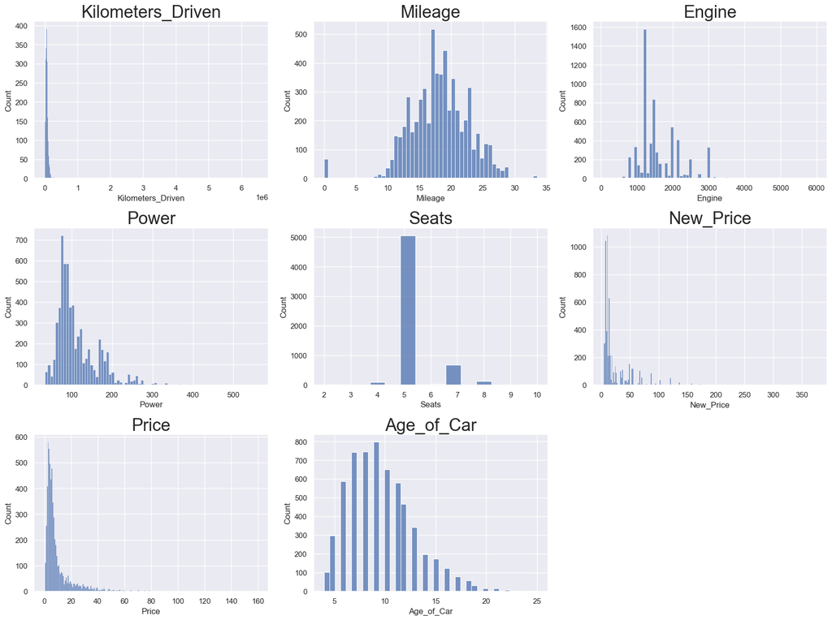

```python
# ------------------
# Performing Univariate Analysis to study the central tendency and dispersion
# Plotting histogram to study distribution
# ------------------

Uni_num = df.select_dtypes(include=np.number).columns.tolist()
plt.figure(figsize=(17, 75))
for i in range(
    len(Uni_num)
):  # creating a loop that will show the plots for the columns in one plot
    plt.subplot(18, 3, i + 1)
    sns.histplot(df[Uni_num[i]], kde=False)
    plt.tight_layout()
    plt.title(Uni_num[i], fontsize=25)

plt.show()
```

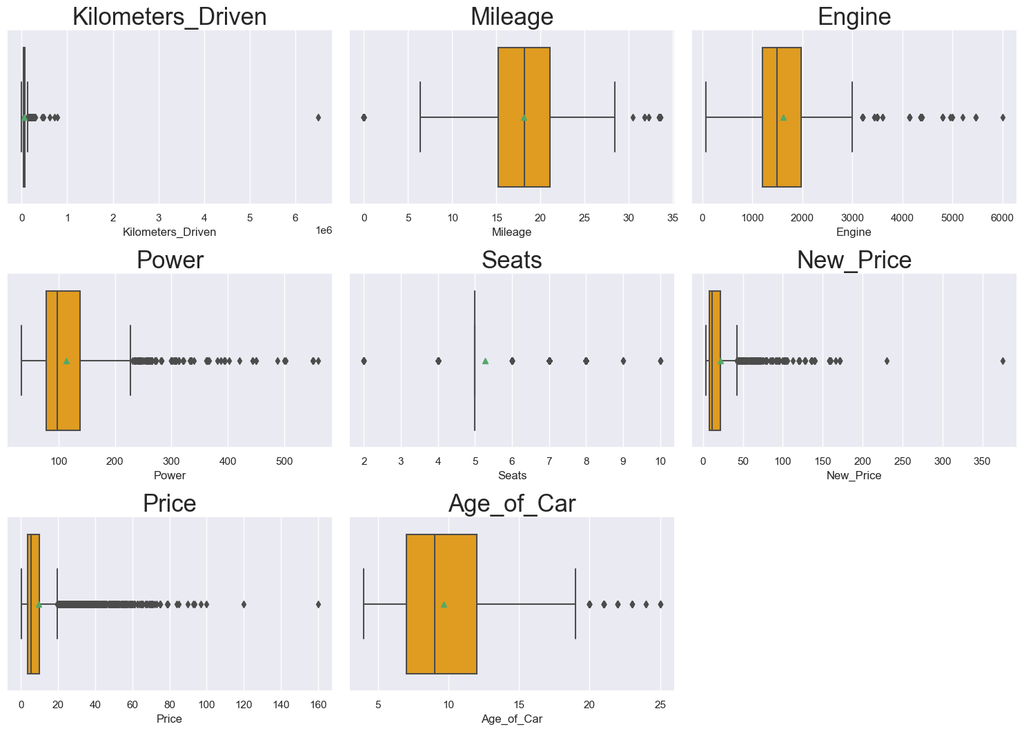

```python
# ---------------
# Plotting a box plot to study central tendency
# ---------------

plt.figure(figsize=(15, 35))
for i in range(len(Uni_num)):
    plt.subplot(10, 3, i + 1)
    sns.boxplot(df[Uni_num[i]], showmeans=True, color="orange")
    plt.tight_layout()
    plt.title(Uni_num[i], fontsize=25)

plt.show()
```

*Observations from both Histogram & Boxplot*

- *Only `Mileage` has a semblance of a normal distribution*
- *`Age_of_Car` is right-skewed and has some outliers.*
- *`Engine & Power`:* *Both columns are right-skwed with a moderate Inter-Quartile Range and several outliers. Power has more outliers comapred to Engine.*
- *`Kilometer_Driven` and `Price`:* *Both these columns are heavily right-skewed, both have a very small IQR and one large outlier in the max end. `Price` column also has several outliers in the higher end.*

  **We will be building models for when the outliers are treated and when they are not treated then decide if the outlier treatment has any effect on the result**
- *`Seat` although Numerical is clearly discrete and not continous. We will convert to Categorical.*

```python
df["Seats"].value_counts(normalize=True) * 100
```

```
5.0     84.017279
7.0     11.197873
8.0      2.226283
4.0      1.644791
6.0      0.515036
2.0      0.265825
10.0     0.083070
9.0      0.049842
Name: Seats, dtype: float64
```

```python
# ----------
# This code takes the DataFrame's discrete numerical column of Seats
#  and creates a new Categorical column (Seats_C)with descriptive labels
# ----------

# Get the numerical column from the dataframe into a series
seats_ps = df["Seats"]

# Define a function to map numerical values to descriptive labels
# Combine 2,6,9 & 10 Seaters into "Others" because they account for only 0.914% combined.
def num_2_cat(num):
    if num == 5:
        return "Five_Seater"
    elif num == 7:
        return "Seven_Seater"
    elif num == 8:
        return "Eight_seater"
    elif num == 4:
        return "Four_Seater"
    else:
        return "Others"  #


# Apply the function to the numerical column and create a new column with the descriptive labels
df["Seats_C"] = df["Seats"].apply(num_2_cat)
```

```python
# Drop the Seats column & convert Seat_C to categorical
df.drop("Seats", axis=1, inplace=True)
df["Seats_C"] = df["Seats_C"].astype("category")

df.info()
```

```
<class 'pandas.core.frame.DataFrame'>
Int64Index: 6019 entries, 0 to 6018
Data columns (total 16 columns):
 #   Column             Non-Null Count  Dtype
---  ------             --------------  -----
 0   Name               6019 non-null   category
 1   Kilometers_Driven  6019 non-null   int64
 2   Fuel_Type          6019 non-null   category
 3   Transmission       6019 non-null   category
 4   Owner_Type         6019 non-null   category
 5   Mileage            6019 non-null   float64
 6   Engine             6019 non-null   float64
 7   Power              6019 non-null   float64
 8   New_Price          6019 non-null   float64
 9   Price              6019 non-null   float64
 10  Car_Brand          6019 non-null   object
 11  Car_Model          6019 non-null   object
 12  Car_Class          6019 non-null   category
 13  Region             6019 non-null   category
 14  Age_of_Car         6019 non-null   int64
 15  Seats_C            6019 non-null   category
dtypes: category(7), float64(5), int64(2), object(2)
memory usage: 597.6+ KB
```

```python
df["Seats_C"].value_counts(normalize=True) * 100
```

```
Five_Seater     84.017279
Seven_Seater    11.197873
Eight_seater     2.226283
Four_Seater      1.644791
Others           0.913773
Name: Seats_C, dtype: float64
```

### **Univariate Analysis of Categorical Variable**

```python
# Create a list of Categorical Variables
cat_col = df.select_dtypes(exclude=np.number).columns.tolist()
cat_col.remove("Name")
cat_col.remove("Car_Model")
print(cat_col)
```

```
['Fuel_Type', 'Transmission', 'Owner_Type', 'Car_Brand', 'Car_Class', 'Region', 'Seats_C']
```

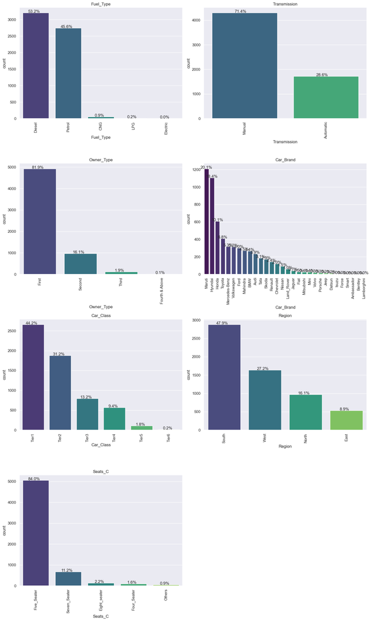

```python
# -----
# Plot a Barchart of each Categorical Column
# -----

plt.figure(figsize=(15, 25))

for i, variable in enumerate(cat_col):
    plt.subplot(4, 2, i + 1)
    order = df[variable].value_counts(ascending=False).index
    ax = sns.countplot(x=df[variable], data=df, order=order, palette="viridis")
    for p in ax.patches:
        percentage = "{:.1f}%".format(100 * p.get_height() / len(df[variable]))
        x = p.get_x() + p.get_width() / 2 - 0.05
        y = p.get_y() + p.get_height()
        plt.annotate(percentage, (x, y), ha="center")
    plt.xticks(rotation=90)
    plt.tight_layout()
    plt.title(variable)
```

*Observations*

- *About 82% of all cars only have one previous owner.*
- *84% of all cars are `Five_seater`*
- *Also, about 71% of the cars are of `Manual` Transmission and about 50% of cars are sold in the `South` region.*
- *About 44% of cars are in `Tier1` i.e at Price below 5.0 Lakhs INR.*
- *We can see that `Diesel` is the most Preferred `Fuel_type` at about 53% followed by Petrol at about 46%. CNG and LPG together make up about 1% of all cars.*
- *`Maruti` & `Hyundai` are the most popular car brands with 38.5%.*
- *`Honda` & `Toyota` are the next most popular brands*
- *Expensive luxury car brands like `Bentley` & `Lamborghini` are very few*
- *Interestingly, Electric `Fuel_Type` is 0.0%. Let's explore this further below...*

```python
df[df["Fuel_Type"] == "Electric"]
```

|  | Name | Kilometers_Driven | Fuel_Type | Transmission | Owner_Type | Mileage | Engine | Power | New_Price | Price | Car_Brand | Car_Model | Car_Class | Region | Age_of_Car | Seats_C |
| --- | --- | --- | --- | --- | --- | --- | --- | --- | --- | --- | --- | --- | --- | --- | --- | --- |
| 4446 | Mahindra E Verito D4 | 50000 | Electric | Automatic | First | 18.15 | 72.0 | 41.0 | 13.58 | 13.00 | Mahindra | E Verito D4 | Tier3 | South | 7 | Five_Seater |
| 4904 | Toyota Prius 2009-2016 Z4 | 44000 | Electric | Automatic | First | 18.15 | 1798.0 | 73.0 | 24.01 | 12.75 | Toyota | Prius 2009-2016 Z4 | Tier3 | West | 12 | Five_Seater |

*Observations*

### **Multivariate Analysis**

### Correlation Matrix

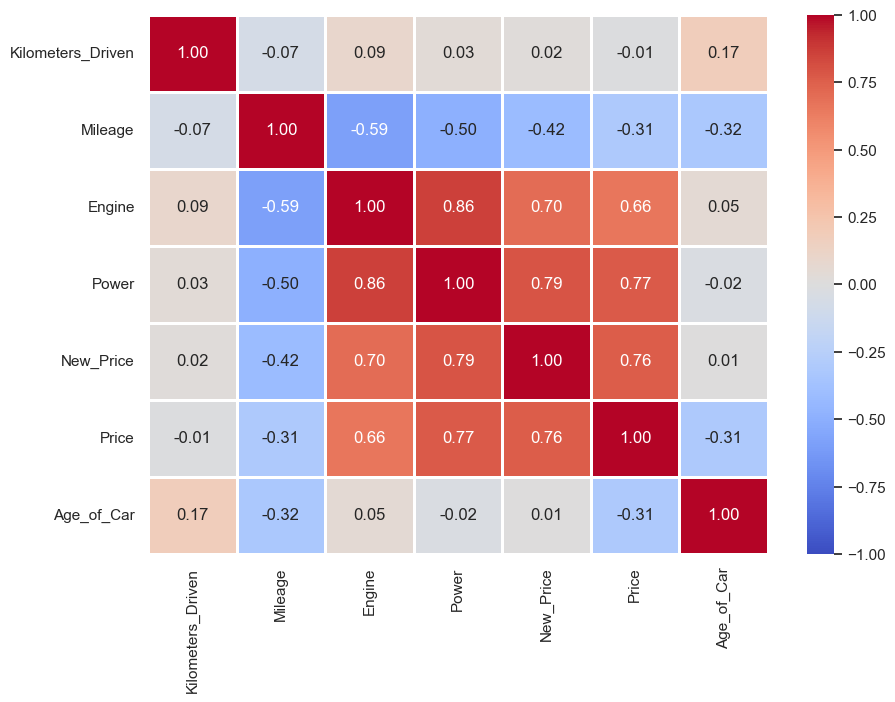

```python
plt.figure(figsize=(10, 7))
sns.heatmap(
    df.corr(), annot=True, vmin=-1, vmax=1, fmt=".2f", cmap="coolwarm", linewidths=0.75
)
plt.show()
```

*Observations*

- *`Price` has a negative correlation with `Age_of_Car` and `Mileage`*
- *`Price` has high positive correlation with `Engine` and `Power`.*
- *`Engine` and `Power` have a very high positive correlation.*
- *`Mileage` has a high negative correlation with `Engine` and `Power`*
- *`Price` has a high positive correlation with `New_Price`. This is to be expected.*

### Analysis of Correlated Variables That Are Noteworthy

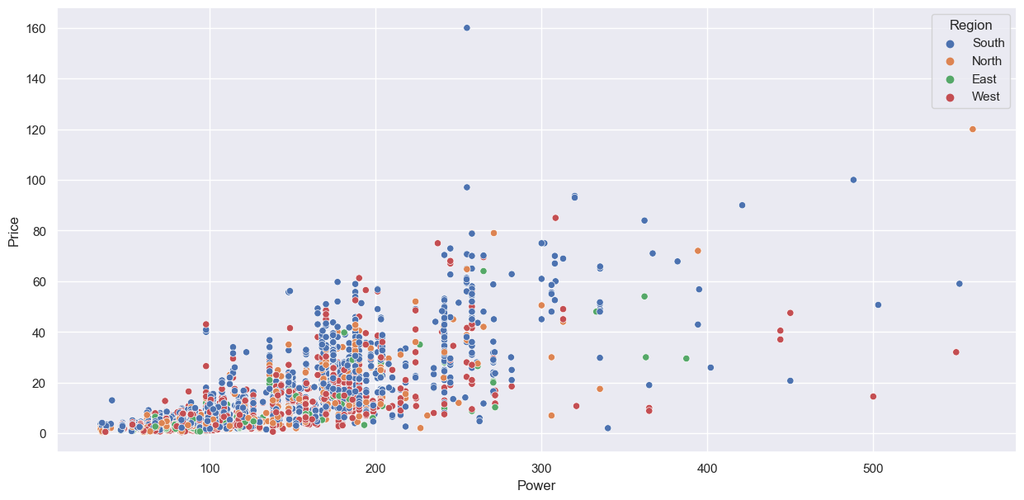

```python
# Price Vs Power Hue on Region
plt.figure(figsize=(15, 7))
sns.scatterplot(data=df, y="Price", x="Power", hue="Region")
plt.show()
```

*Observations*

- *`Price` increase with `Power`. This trend is more pronounced in the `South` Region.*

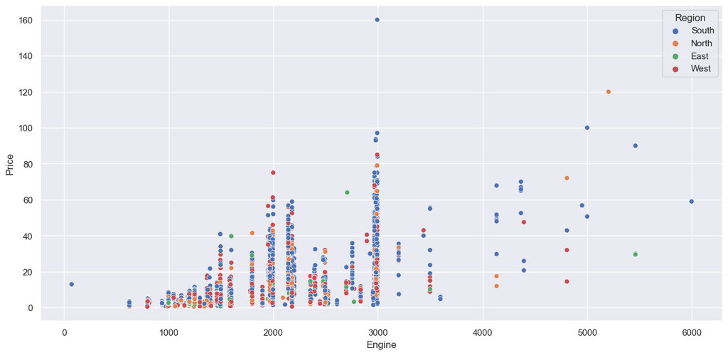

```python
# Price Vs Engine Hue on Region
plt.figure(figsize=(15, 7))
sns.scatterplot(data=df, y="Price", x="Engine", hue="Region")
plt.show()
```

*Observations*

- *Engine capacity increases Price of cars also increase...however with several exceptions.*

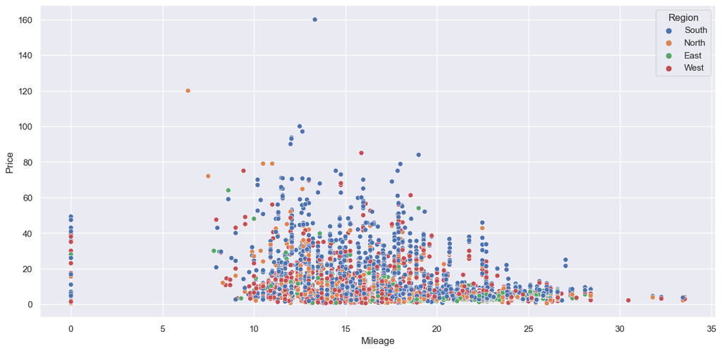

```python
# Price Vs Mileage hue Region
plt.figure(figsize=(15, 7))
sns.scatterplot(data=df, y="Price", x="Mileage", hue="Region")
plt.show()
```

*Observations*

- *Price and Mileage have a negative correlation

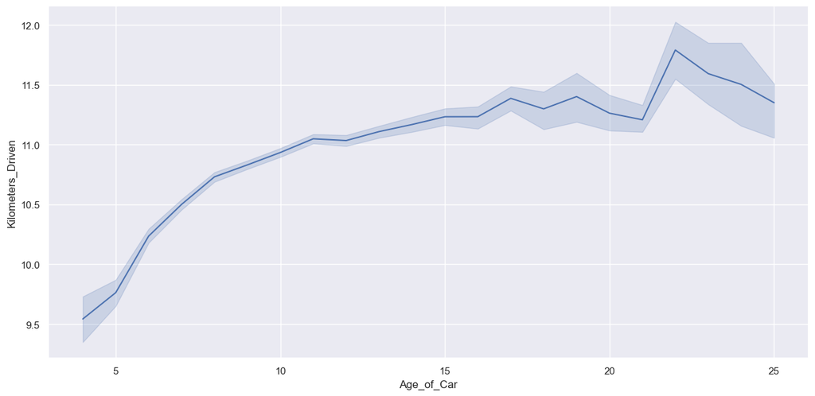

```python
# Kilometers_Driven Vs Age_of_Car

plt.figure(figsize=(15, 7))
# We will do a log transform to a manageable scale...since the range for Kilometers is very wide
sns.lineplot(x="Age_of_Car", y=np.log(df["Kilometers_Driven"]), data=df)
```

*Observations*

- *As expected there's a positive correlation of `Age_of_Car` and `Kilimeters_Driven` as older cars have more usage*

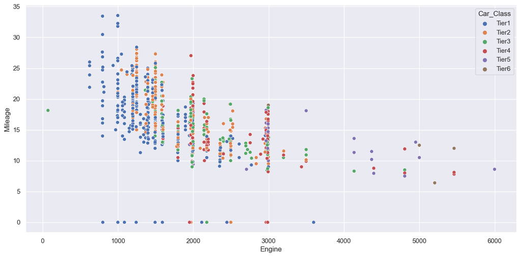

```python
# Engine Vs Mileage hue Car_Class
plt.figure(figsize=(15, 7))
sns.scatterplot(x="Engine", y="Mileage", hue="Car_Class", data=df)
```

*Observations*

- *`Engine` and `Mileage` are negatively correlated*
- *`Tier1` cars have higher `Mileage`.*

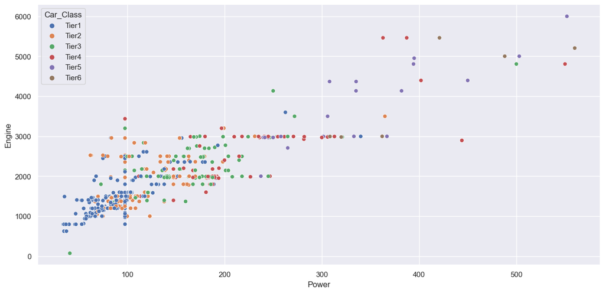

```python
# Engine vs Power hue on Car_Class
plt.figure(figsize=(15, 7))
sns.scatterplot(data=df, y="Engine", x="Power", hue="Car_Class")
plt.show()
```

*Observations*

- *The 2 variables (`Power` & `Engine`) have a positive correlation.
- *This suggest multicolinearity between `Engine` and `Power`.*

### Answering Some Key Questions

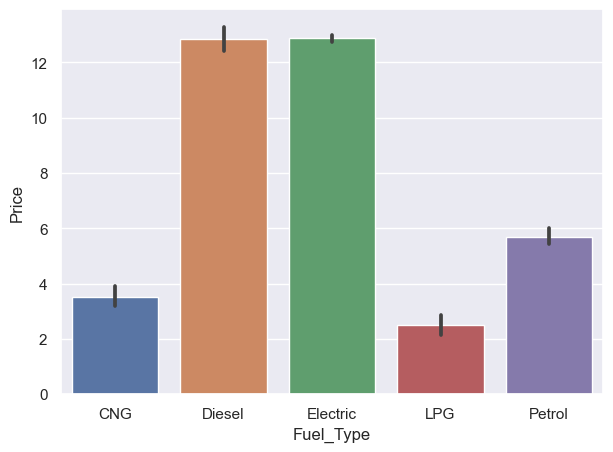

```python
# Does Fuel_Type affect car Price?

plt.figure(figsize=(7, 5))
sns.barplot(data=df, x="Fuel_Type", y="Price")
```

*Observations*

- *Interestingly, `Electric` cars have an equal `Price` range compared to `Diesel` cars.*
- *However, we know that there are only two cars with `Electric` `Fuel_Type` in this data, which is a very small sample size.*

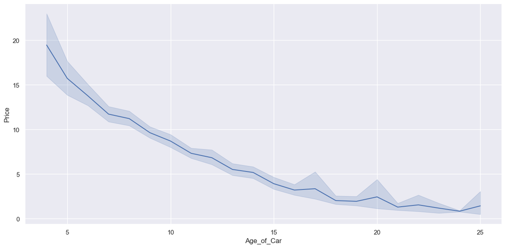

```python
# -----
# How Does The Age_of_Car of Manufacture affect Price?
# -----
plt.figure(figsize=(15, 7))
sns.lineplot(x="Age_of_Car", y="Price", data=df)
```

*Observations*

- *As expected, as `Age_of_Car` increases, the `Price` of car decreases*

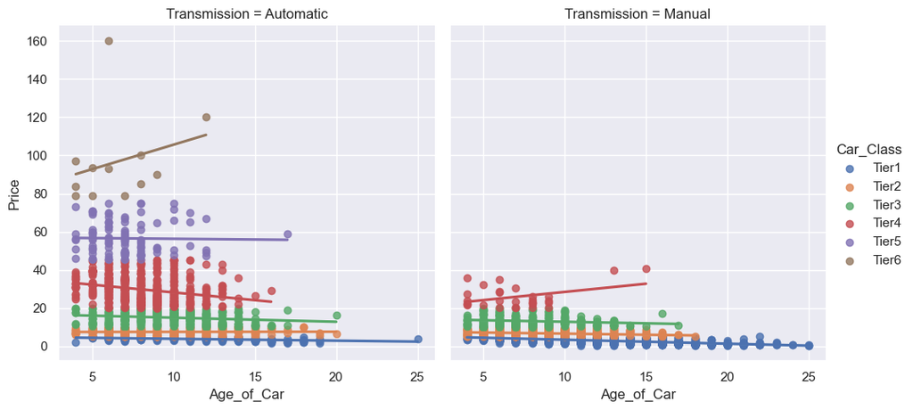

```python
# ---------------------------
# How Does The Age_of_Car of Manufacture affect Price?
# ---------------------------

sns.lmplot(
    data=df, x="Age_of_Car", y="Price", hue="Car_Class", col="Transmission", ci=False
)
plt.show()
```

*Observations*

- *Interestingly older `Tier6` cars (luxury/expensive cars) cost more than newer ones...there is a positive correlation between `Price` & `Age_of_Car` for luxury/expensive cars. This suggests that `Tier6` cars become vintage with time.*
- *No `Tier5` or `Tier6` (the more expensive cars) have manual Transmission.*

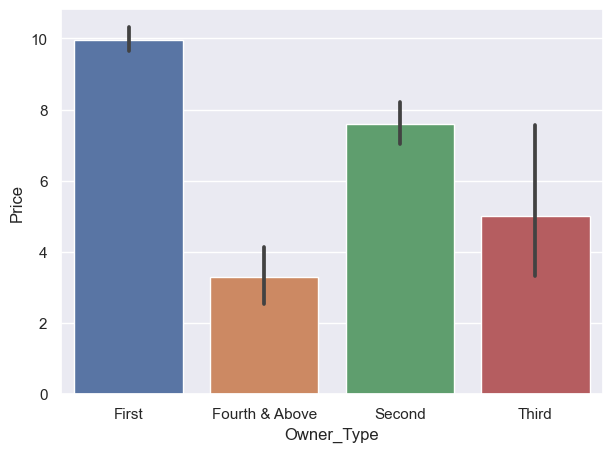

```python
# Does type of ownership affect car Price?

plt.figure(figsize=(7, 5))
sns.barplot(data=df, x="Owner_Type", y="Price")
```

*Observations*

- *Type of ownership greatly influences the `Price`*
- *Cars with `First` time owner are more expensive folowed by `Second` time owner then `Third` and so on.*

## **Variable Transformation**

```python
# Update num_col
num_col = df.select_dtypes(include=np.number).columns.tolist()
```

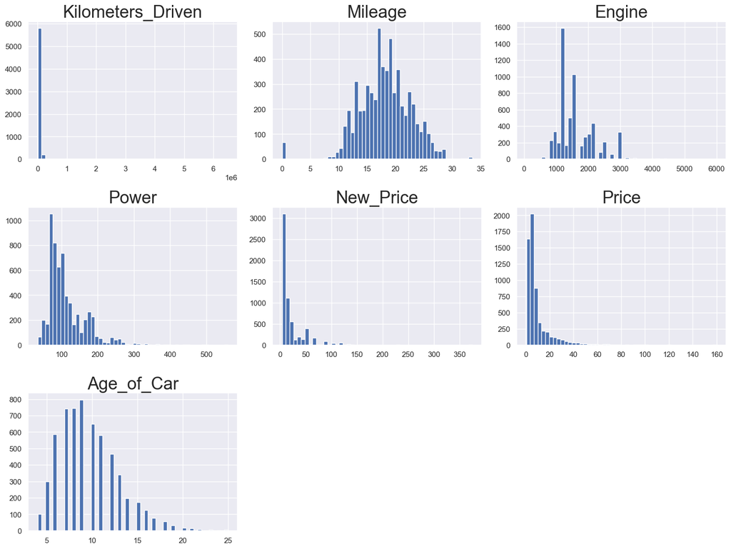

```python
# Plot a histogram of all Numerical columns

plt.figure(figsize=(15, 45))

for i in range(len(num_col)):
    plt.subplot(12, 3, i + 1)
    plt.hist(df[num_col[i]], bins=50)
    plt.tight_layout()
    plt.title(num_col[i], fontsize=25)

plt.show()
```

*Observations*

- *The columns are heavily skewed. Only `Mileage` has a semblance of a normal distribution.

```python
# -----
# Perform a log transformation of the numerical columns except for 'Mileage'
# -----

# creating a copy of the dataframe
df2 = df.copy()

# using log transforms on some columns
for col in num_col:
    if (
        col != "Mileage"
    ):  # Skip Mileage because Mileage has a semblance of normal distribution and log will not help it
        df2[col + "_log"] = np.log(df2[col] + 1)

# Overwrite the orinal column with the log columns
df2["Age_of_Car"] = df2["Age_of_Car_log"]
df2["Kilometers_Driven"] = df2["Kilometers_Driven_log"]
df2["Engine"] = df2["Engine_log"]
df2["Power"] = df2["Power_log"]
df2["New_Price"] = df2["New_Price_log"]
df2["Price"] = df2["Price_log"]

# dropping the log columns
df2.drop(
    [
        "Age_of_Car_log",
        "Kilometers_Driven_log",
        "Engine_log",
        "Power_log",
        "New_Price_log",
        "Price_log",
    ],
    axis=1,
    inplace=True,
)
df2.head()
```

|  | Name | Kilometers_Driven | Fuel_Type | Transmission | Owner_Type | Mileage | Engine | Power | New_Price | Price | Car_Brand | Car_Model | Car_Class | Region | Age_of_Car | Seats_C |
| --- | --- | --- | --- | --- | --- | --- | --- | --- | --- | --- | --- | --- | --- | --- | --- | --- |
| 0 | Maruti Wagon R LXI CNG | 11.184435 | CNG | Manual | First | 26.60 | 6.906755 | 4.080246 | 1.873339 | 1.011601 | Maruti | Wagon R LXI CNG | Tier1 | West | 2.639057 | Five_Seater |
| 1 | Hyundai Creta 1.6 CRDi SX Option | 10.621352 | Diesel | Manual | First | 19.67 | 7.367077 | 4.845761 | 2.836737 | 2.602690 | Hyundai | Creta 1.6 CRDi SX Option | Tier3 | West | 2.197225 | Five_Seater |
| 2 | Honda Jazz V | 10.736418 | Petrol | Manual | First | 18.20 | 7.090077 | 4.496471 | 2.262804 | 1.704748 | Honda | Jazz V | Tier1 | South | 2.564949 | Five_Seater |
| 3 | Maruti Ertiga VDI | 11.373675 | Diesel | Manual | First | 20.77 | 7.130099 | 4.497139 | 2.507157 | 1.945910 | Maruti | Ertiga VDI | Tier2 | South | 2.484907 | Seven_Seater |
| 4 | Audi A4 New 2.0 TDI Multitronic | 10.613271 | Diesel | Automatic | Second | 15.20 | 7.585281 | 4.954418 | 3.991573 | 2.930660 | Audi | A4 New 2.0 TDI Multitronic | Tier3 | South | 2.397895 | Five_Seater |

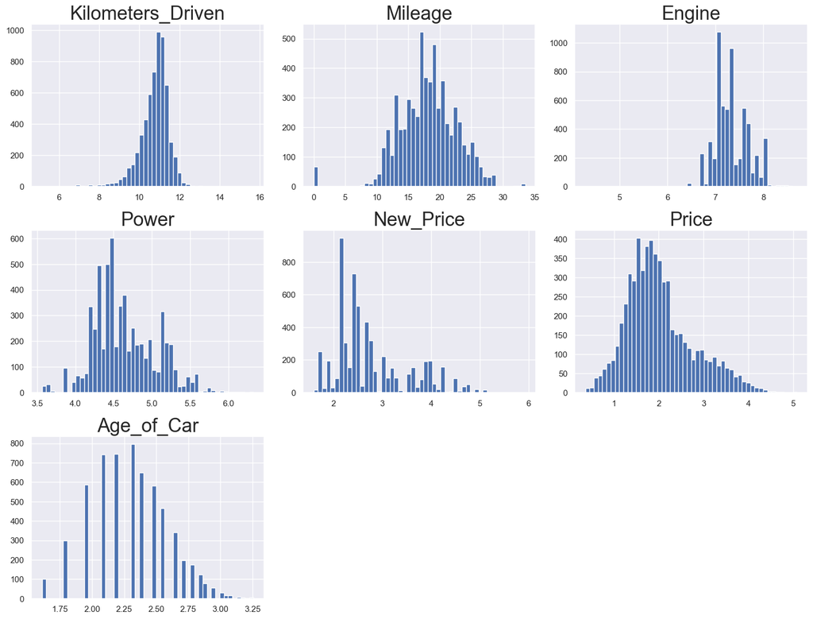

```python
# Get the transfromed numerical column
num_col2 = df2.select_dtypes(include=np.number).columns.tolist()

# Plot a histogram of all Numerical columns to check the effect of the log transformation
plt.figure(figsize=(15, 45))

for i in range(len(num_col2)):
    plt.subplot(12, 3, i + 1)
    plt.hist(df2[num_col2[i]], bins=50)
    plt.tight_layout()
    plt.title(num_col2[i], fontsize=25)

plt.show()
```

*Observations*

- *The columns are still skewed, but not as heavily as before.*

## **Outlier Treatment**

```python
# Treating outliers by flooring and capping
def outliers_treatment(df, col):

    Q1 = df[col].quantile(0.25)  # 25th quantile
    Q3 = df[col].quantile(0.75)  # 75th quantile
    IQR = Q3 - Q1
    Lower_Whisker = Q1 - 1.5 * IQR
    Upper_Whisker = Q3 + 1.5 * IQR

    # All the values samller than Lower_Whisker will be assigned value of Lower_whisker
    # And all the values above upper_whishker will be assigned value of upper_Whisker
    df[col] = np.clip(df[col], Lower_Whisker, Upper_Whisker)

    return df


def treat_outliers(df, col_list):

    for c in col_list:
        df = outliers_treatment(df, c)

    return df
```

**To decide if the outliers have a negative effect to the linear model, we will build a Predictive model with and without Outlier treatment and compare.**

```python
# Making the first copy for model 1. This will be used for the model with outlier treatment
m1_df = df2.copy()

# Making the second copy for model 2. This will be used for the model without outlier treatment
m2_df = df2.copy()
```

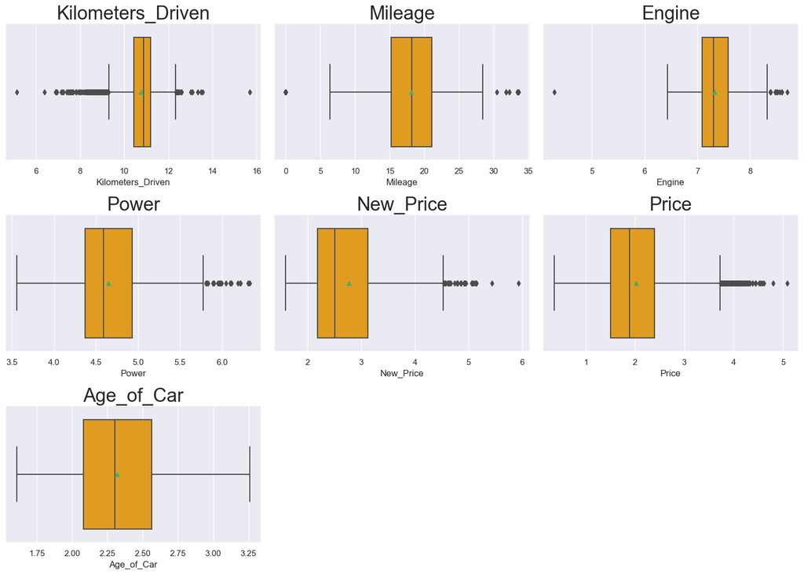

```python
# -----
# Create BoxPlots of Numerical columns
# This shows outliers in all the variable distributions
# -----

plt.figure(figsize=(15, 35))
for i in range(len(num_col2)):
    plt.subplot(10, 3, i + 1)
    sns.boxplot(m1_df[num_col2[i]], showmeans=True, color="orange")
    plt.tight_layout()
    plt.title(num_col2[i], fontsize=25)

plt.show()
```

```python
# -----
# Treating Outliers:
# We are treating outliers by flooring and capping
# -----
m1_df = treat_outliers(m1_df, num_col2)
```

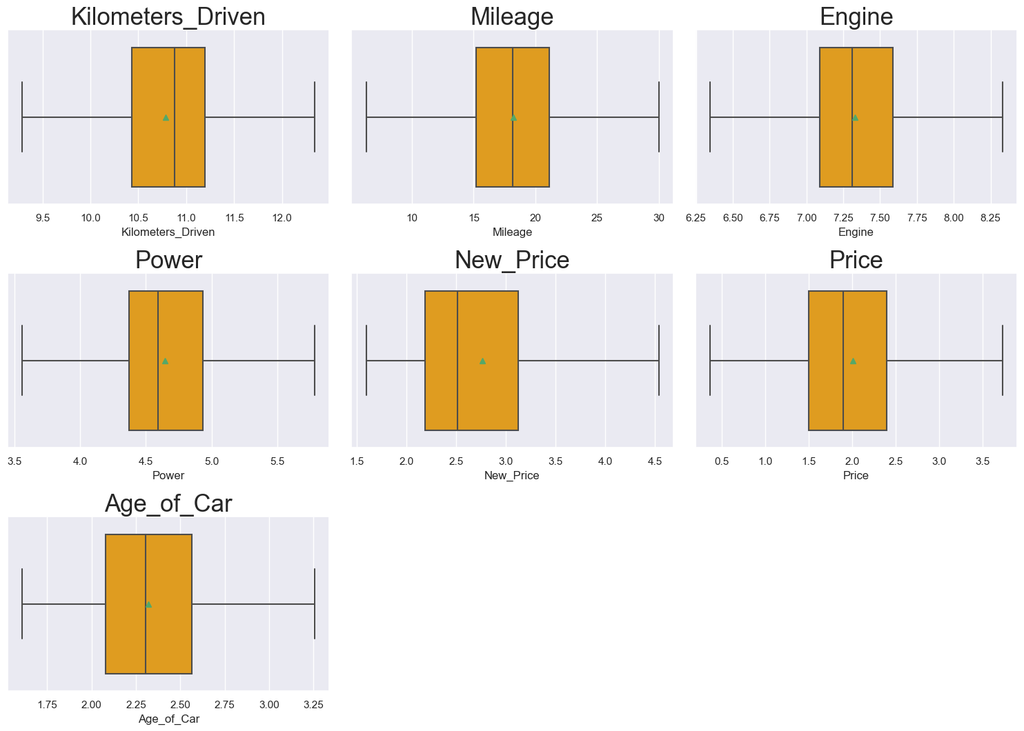

```python
# checking if the outliers are treated
plt.figure(figsize=(15, 35))
for i in range(len(num_col2)):
    plt.subplot(10, 3, i + 1)
    sns.boxplot(m1_df[num_col2[i]], showmeans=True, color="orange")
    plt.tight_layout()
    plt.title(num_col2[i], fontsize=25)

plt.show()
```

*Observations*

- *Outliers for all the Numerical columns have been treated*
- *We will build a model with this treated dataset to analyse the Price*

# **Model Building**

## **Building Model 1 - Model with Treated Outliers.**

### Define Dependent & Independent Variables

```python
# Drop the Model column as we will not be needing it.
# We will be using only the Brand
m1_df.drop("Car_Model", axis=1, inplace=True)

# Defining X and y variables
X1 = m1_df.drop(["Name", "Price"], axis=1)

y1 = m1_df[["Price"]]

print(X1.shape)
print(y1.shape)
```

```
(6019, 13)
(6019, 1)
```

### Creating Dummy Variables

```python
# Creating Dummy Variabls for the Categorical Columns
# Dummy variable will be used as independent variables
X1 = pd.get_dummies(
    X1,
    columns=[
        "Fuel_Type",
        "Transmission",
        "Owner_Type",
        "Car_Class",
        "Region",
        "Seats_C",
        "Car_Brand",
    ],
    drop_first=True,
)
```

### Split the Data into Train and Test

```python
# Split the data into 70% train and 30% test

# keeping random_state = 7 ensuring datasplit remains consistent
X1_train, X1_test, y1_train, y1_test = train_test_split(
    X1, y1, test_size=0.3, random_state=7
)
```

### Fitting Linear Model

```python
# Fitting linear model

# Model Object
lin_reg_model1 = LinearRegression()

# Fit the model
lin_reg_model1.fit(X1_train, y1_train)

# Print the Intercept
print("Intercept of the linear equation:", lin_reg_model1.intercept_)
print("." * 60)

# Print the Coefficients of each Independent Variable
for idx, col_name in enumerate(X1_train.columns):
    print("The coefficient for {} is {}".format(col_name, lin_reg_model1.coef_[0][idx]))
```

```
Intercept of the linear equation: [0.77099689]
............................................................
The coefficient for Kilometers_Driven is -0.03318477573363766
The coefficient for Mileage is 0.003348136932232265
The coefficient for Engine is 0.13548603798569409
The coefficient for Power is 0.32737430224637465
The coefficient for New_Price is 0.1649874899087921
The coefficient for Age_of_Car is -0.6337356856160601
The coefficient for Fuel_Type_Diesel is 0.045682280724547886
The coefficient for Fuel_Type_Electric is 0.6647185437936256
The coefficient for Fuel_Type_LPG is 0.02965984322806675
The coefficient for Fuel_Type_Petrol is -0.04149561035083671
The coefficient for Transmission_Manual is -0.05542390773421413
The coefficient for Owner_Type_Fourth & Above is -0.052111726615686756
The coefficient for Owner_Type_Second is -0.054527041093839046
The coefficient for Owner_Type_Third is -0.13876406112433903
The coefficient for Car_Class_Tier2 is 0.25424235250570276
The coefficient for Car_Class_Tier3 is 0.5510180725906235
The coefficient for Car_Class_Tier4 is 0.8779309934903108
The coefficient for Car_Class_Tier5 is 0.9228433854326108
The coefficient for Car_Class_Tier6 is 0.648142444023839
The coefficient for Region_North is -0.06601552347874493
The coefficient for Region_East is -0.1453856494556845
The coefficient for Region_West is -0.05097729492999495
The coefficient for Seats_C_Five_Seater is -0.0885132805230748
The coefficient for Seats_C_Four_Seater is -0.05613937206637921
The coefficient for Seats_C_Others is 0.03797831487112278
The coefficient for Seats_C_Seven_Seater is -0.010013622977545433
The coefficient for Car_Brand_Audi is 0.03827803186128203
The coefficient for Car_Brand_BMW is 0.046930231091760824
The coefficient for Car_Brand_Bentley is 0.5212249051845387
The coefficient for Car_Brand_Chevrolet is -0.25358002789966827
The coefficient for Car_Brand_Datsun is -0.2079971770353714
The coefficient for Car_Brand_Fiat is -0.21977824879979455
The coefficient for Car_Brand_Force is -0.01665370219706732
The coefficient for Car_Brand_Ford is -0.10388767777426658
The coefficient for Car_Brand_Honda is -0.07466597988349744
The coefficient for Car_Brand_Hyundai is -0.08204883787610759
The coefficient for Car_Brand_Isuzu is -0.23109616426366072
The coefficient for Car_Brand_Jaguar is 0.08657607214014708
The coefficient for Car_Brand_Jeep is -0.015459344011444675
The coefficient for Car_Brand_Lamborghini is 0.9928902558444013
The coefficient for Car_Brand_Land_Rover is 0.18636135665054412
The coefficient for Car_Brand_Mahindra is -0.1683694805392837
The coefficient for Car_Brand_Maruti is -0.029018609509905424
The coefficient for Car_Brand_Mercedes-Benz is 0.05676657968903118
The coefficient for Car_Brand_Mini is 0.1873217291782363
The coefficient for Car_Brand_Mitsubishi is -0.0770047467674247
The coefficient for Car_Brand_Nissan is -0.08174956045778448
The coefficient for Car_Brand_Porsche is 0.2231249110541901
The coefficient for Car_Brand_Renault is -0.06953725497888645
The coefficient for Car_Brand_Skoda is -0.10843048829490089
The coefficient for Car_Brand_Smart is -1.5654144647214707e-14
The coefficient for Car_Brand_Tata is -0.28263691823211196
The coefficient for Car_Brand_Toyota is -0.036692268319728896
The coefficient for Car_Brand_Volkswagen is -0.05069762047203394
The coefficient for Car_Brand_Volvo is 0.010261592889612807
```

### Model Performance Check

```python
# -----
# User Defined functions to compute adjusted R-squared
# -----
def adj_r2_score(predictors, targets, predictions):
    r2 = r2_score(targets, predictions)
    n = predictors.shape[0]
    k = predictors.shape[1]
    return 1 - ((1 - r2) * (n - 1) / (n - k - 1))

# -----
# User Defined function to compute the performance of a regression model using different metrics
# -----
def model_performance_regression(model, predictors, target):
    """
    model: regressor
    predictors: independent variables
    target: dependent variable
    """

    # predicting using the independent variables
    pred = model.predict(predictors)

    r2 = r2_score(target, pred)  # to compute R-squared
    adjr2 = adj_r2_score(predictors, target, pred)  # to compute adjusted R-squared
    rmse = np.sqrt(mean_squared_error(target, pred))  # to compute RMSE
    mae = mean_absolute_error(target, pred)  # to compute MAE

    mape = np.abs((target - pred)) / target * 100

    # creating a dataframe of metrics
    df_perf = pd.DataFrame(
        {
            "RMSE": rmse,
            "MAE": mae,
            "R-squared": r2,
            "Adj. R-squared": adjr2,
        },
        index=[0],
    )

    type(r2)

    return df_perf
```

```python
# Checking model performance on train set
print("Training Performance\n")
lin_reg_model_train_perf1 = model_performance_regression(
    lin_reg_model1, X1_train, y1_train
)
lin_reg_model_train_perf1
```

```
Training Performance
```

|  | RMSE | MAE | R-squared | Adj. R-squared |
| --- | --- | --- | --- | --- |
| 0 | 0.144011 | 0.111532 | 0.960336 | 0.959811 |

```python
# Checking model performance on test set
print("Test Performance\n")
lin_reg_model_test_perf1 = model_performance_regression(
    lin_reg_model1, X1_test, y1_test
)
lin_reg_model_test_perf1
```

```
Test Performance
```

|  | RMSE | MAE | R-squared | Adj. R-squared |
| --- | --- | --- | --- | --- |
| 0 | 0.151828 | 0.110001 | 0.957508 | 0.956173 |

**Observations**

## **Building Model 2 - Model with Untreated Outliers.**

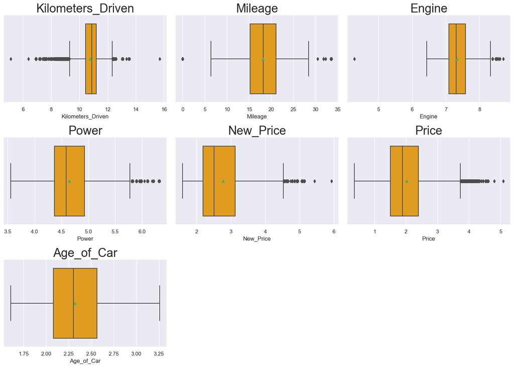

```python
# -----
# Create BoxPlots of Numerical columns to shows that the dataset m2_df has untreated outliers
# -----

plt.figure(figsize=(15, 35))
for i in range(len(num_col2)):
    plt.subplot(10, 3, i + 1)
    sns.boxplot(m2_df[num_col2[i]], showmeans=True, color="orange")
    plt.tight_layout()
    plt.title(num_col2[i], fontsize=25)

plt.show()
```

### Define Dependent & Independent Variables

```python
# Drop the Model column as we will not be needing it.
# We will be using only the Brand
m2_df.drop("Car_Model", axis=1, inplace=True)

# Defining X and y variables
X2 = m2_df.drop(["Name", "Price"], axis=1)

y2 = m2_df[["Price"]]

print(X2.shape)
print(y2.shape)
```

```
(6019, 13)
(6019, 1)
```